# HW11: Data Visualization I (con’t)

Ryan McAnulty

28 July 2020

## Loading required libraries

```r
library(tidyverse)
library(here)
library(GGally)
library(patchwork)
```

## Importing aegla_crabs.csv data

```r
aegla <-                            # Importing and naming aegla_crabs.csv data
  read.csv(here("data",
                "aegla_crabs.csv"))
aegla_wrangled <- aegla %>%         # Wrangling data
  select(-"Site",                   # Removing columns Site, AT, WT, Crab, Shrimp, Aeglam, AeglaFE, and AeglaFo
         -"AT",
         -"WT",
         -"Crab",
         -"Shrimp",
         -"Aeglam",
         -"AeglaFe",
         -"AeglaFo") %>%
  drop_na() %>%                     # Dropping remaining NAs
  mutate(row_order = 1:nrow(.))     # Creating arbitrary variable for plotting purposes. Setting number of rows 1 to 55.
```

## Looking for possible outliers

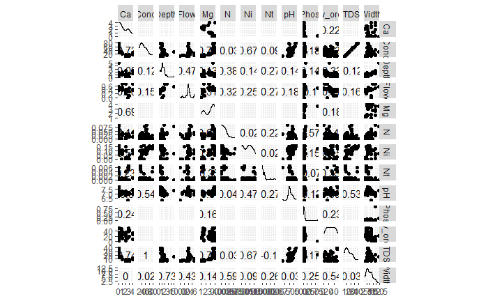

```r
aegla_wrangled %>% ggscatmat(columns = 1:13) # It is tiny in the notebook, but looking at it in the console obvious outliers can be seen. After looking at these and running multiple cleveland plots, I think these are the three possible outlier data points, as displayed by the three plots below.
```

## Displaying three cleveland plots to determine true outliers after reviewing above plots

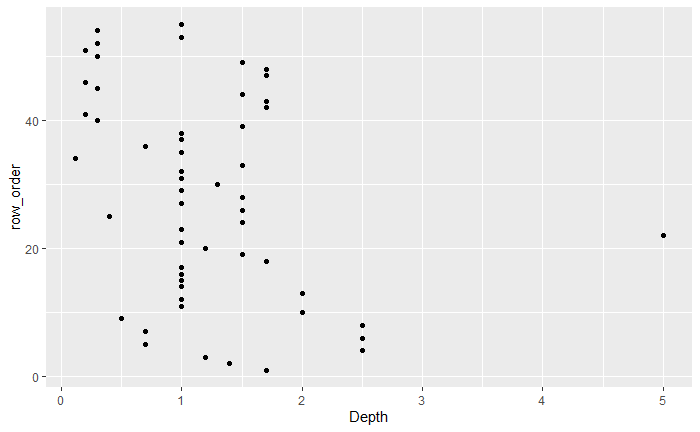

```r
aegla_wrangled %>%
  ggplot(aes(x = Depth,           # Testing Depth outlier
             y = row_order)) +
  geom_point() +
  labs(x = "Depth",
       y = "row_order")
```

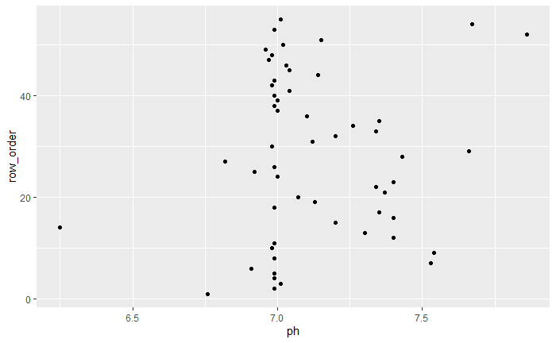

```r
aegla_wrangled %>%
  ggplot(aes(x = pH,              # Testing pH outlier
             y = row_order)) +
  geom_point() +
  labs(x = "ph",
       y = "row_order")
```

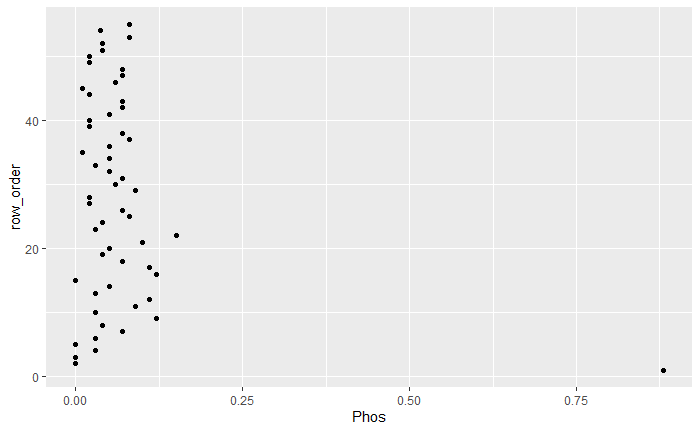

```r
aegla_wrangled %>%
  ggplot(aes(x = Phos,            # Testing Phos Concentration outlier
             y = row_order)) +
  geom_point() +
  labs(x = "Phos",
       y = "row_order")
```

Three possible outliers are depth being 5, pH being 6.25, and Phos Concentration being 0.88. I could see all of these three points as outliers, but the pH of 6.25 and Depth of 5 are the weakest ones.  
The pH is not that low at all compared to the other values. The depth at 5 is high, but it also corresponds to the width of the stream being 12. This slightly deeper and wider part of the stream is certainly possible.  
I would ultimately say that the Phosphorus concentration of 0.88 from site AG1KN1 is insanely high compared to every other sample and must be due to an agricultural contamination. Looking at the original data, it is also only one of two sites where no data from specimen counts is available.

## Making Cleveland plots of N, Ni, Nt, and Cond, putting in 2x2 grid (A very slight look into the Nitrogen Cycle)

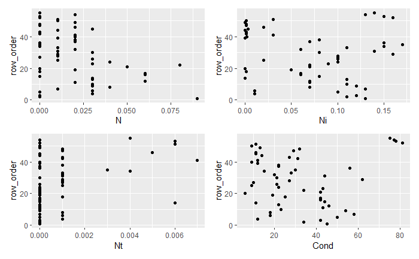

```r
p_N <-
  aegla_wrangled %>%                # Saving Nitrogen Concentration as p_N
  ggplot(aes(y = row_order)) +
  geom_point(aes(x = N))
p_Ni <- aegla_wrangled %>%          # Saving Nitrate Concentration as p_Ni
  ggplot(aes(y = row_order)) +
  geom_point(aes(x = Ni))

p_Nt <- aegla_wrangled %>%          # Saving Nitrite COncentration as p_Nt
  ggplot(aes(y = row_order)) +
  geom_point(aes(x = Nt))
p_Cond <- aegla_wrangled %>%        # Saving Conductivity as p_Cond
  ggplot(aes(y = row_order)) +
  geom_point(aes(x = Cond))
p_N + p_Ni + p_Nt + p_Cond
```

## Making historgram for Flow, pH, Width

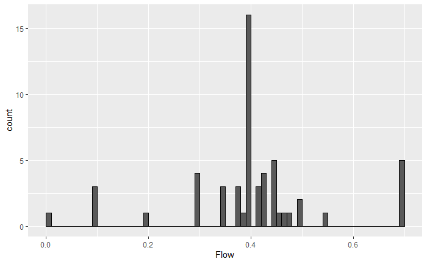

```r
h1_Flow <- aegla_wrangled %>%
  ggplot() +
  geom_histogram(
    aes(x = Flow),              # Making a histogram for Flow
    binwidth = .01,             # Setting binwidth to .01
    boundary = 0,
    closed = "right",
    color = "black"
  )
h1_pH <- aegla_wrangled %>%
  ggplot() +
  geom_histogram(
    aes(x = pH),                # Making a histogram for pH
    binwidth = .01,             # Setting binwidth to .01
    boundary = 0,
    closed = "right",
    color = "black"
  )
h1_Width <- aegla_wrangled %>%
  ggplot() +
  geom_histogram(
    aes(x = Width),             # Making a histrogram for Width
    binwidth = .1,              # Setting binwidth to 0.1
    boundary = 0,
    closed =  "right",
    color = "black"
  )
h1_Flow                         # Displaying the three histograms
```

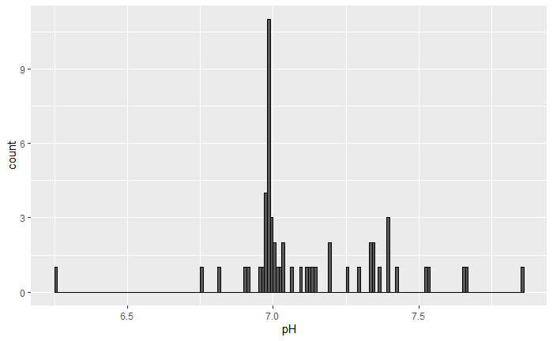

```r
h1_pH
```

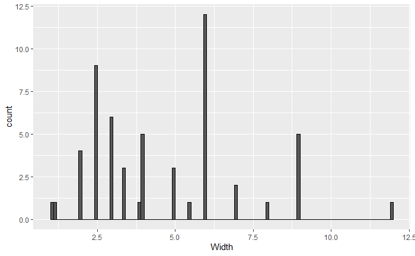

```r
h1_Width
```

I felt that these three had the most normalization of any of the variables, thus best for histograms. I chose the binwidths of .01, .01, and .1 respectively due to data being lost or spaced out even more than it is at other values. Flow does seem to center around 0.4 with some variance. pH is mostly neutral but has some variance. Width centers around 6.0 also, 2.5 also with some variance. In my opinion, as meaningless at this point in my career as it might be, there just isn’t enough data points per variable to really see any meaningful trends in these variables. The more data points, the more trends can be seen.

## Producing density plots for Flow, pH, and Width

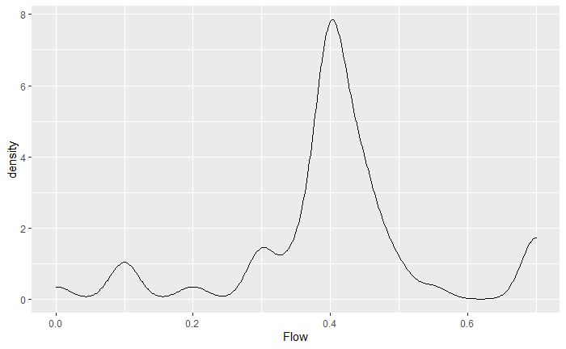

```r
d_Flow <- aegla_wrangled %>%
  ggplot(aes(x = Flow)) +       # Making a density plot for Flow
  geom_density()
d_pH <- aegla_wrangled %>%      # Making a density plot for pH
  ggplot(aes(x = pH)) +
  geom_density()
d_Width <- aegla_wrangled %>%   # Making a density plot for Width
  ggplot(aes(x = Width)) +
  geom_density()
d_Flow                          # Displaying the density plots
```

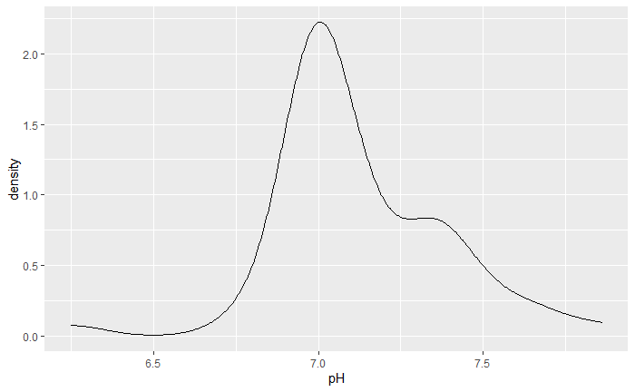

```r
d_pH
```

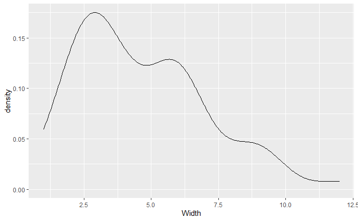

```r
d_Width
```

The first two density plots follows what I found in the histograms, but the Width plot shows more of a grouping around 2.7 or so than I noticed.

## Displaying all three histograms and density plots in a 2 x 3 matrix

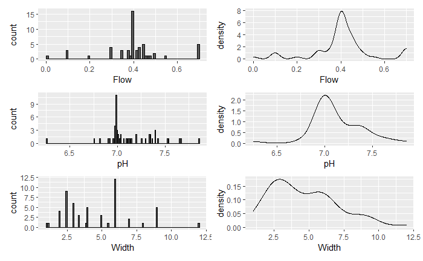

```r
h1_Flow + d_Flow + h1_pH + d_pH + h1_Width + d_Width + plot_layout(ncol = 2, nrow = 3)
```

This display of all six plots is much more handy than going back and forth and reviewing each separately

## Running ggpairs to show relationships between variables.

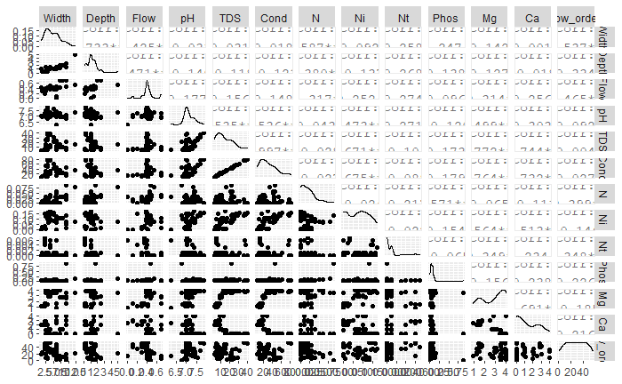

```r
aegla_wrangled %>%
  ggpairs()
```